# WK05

2025-10-30

#### **01 OSM Part** (ShapeFile)

**Step One:** We are Going to Use *“Geofabrik”* Website and download the server  
**Step Two:** Navigate to Europe > UK > England > Greater London  
**Step Three:** Download **greater-london-latest-free.shp.zip**  
**Step Four:** Unzip File and Save it into DATA

#### **02 London Boroughs** (Boundry > ShapeFile)

**Step One:** Get the data go to the London data store.  
**Step Two:** Statistical GIS boundary files for London.  
**Step Three:** Download the **statistical-gis-boundaries-london.zip**  
**Step Four:** Unzip the Data and save it to DATA folder.

#### **03 World cities** (Context > ShapeFile)

**Step Five:** Download them from the ArcGIS HUB > Download > Shapefile.

#### **04 UK Outline** (Context > Shapefile)

**Step Six:** Download GADM data for the UK.

#### **05 Airbnb:** (CSV)

**Step Seven:** Download the **listings.csv** from the inside airbnb website for London.

#### **06 Goal:**

1. Compare Airbnb and hotels across London Boroughs
2. Join the Airbnbs to the MSOAs and sum (i.e. how many are in each MSOA)
3. Join the Hotels to the MSOAs and sum

Lets use st_join() joining based on a column, what we want to make is that each hotel will be a new row. each hotel will have also a borough column.

group by and summarize

a spatial join in like a left join, the boroughs will always exist.

using st feature to see if st_contains(A, B) - Does A (boroughs) contain B (OSM)  
Returns a list of boroughs (33 rows) and in each borough a list of hotels

we take the length of that list per borough

**Mapping** loading your shape object with tm_shape() (here sf object, but it could be a raster) setting the map layer (e.g. polygons (tm_polygons()), symbols (tm_symbols()),raster (tm_raster()), text (tm_text()), lines (tm_lines()) etc). applying a derived function (e.g. border (tm_borders()), fill (tm_fill()), markers (tm_markers()).

[output not shown]

[output not shown]

[output not shown]

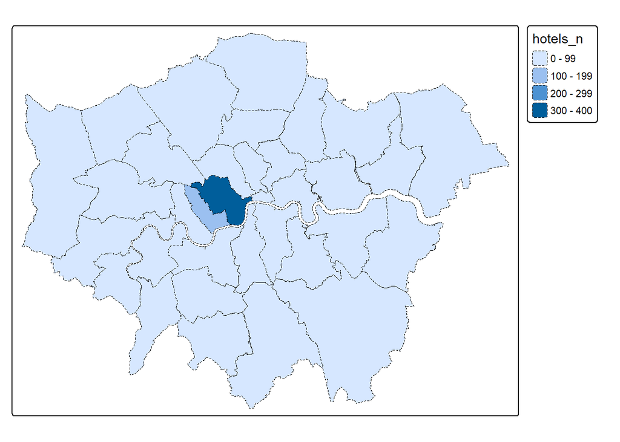

```r
# set the shape
tm1 <- tm_shape(Accomodation_contained) +
  # set the map layer
  # try changing this to tm_symbols()
  tm_polygons("hotels_n",
              col = "black", lwd=0.5, lty="dashed",)

# plot the map
tm1
```

just borders

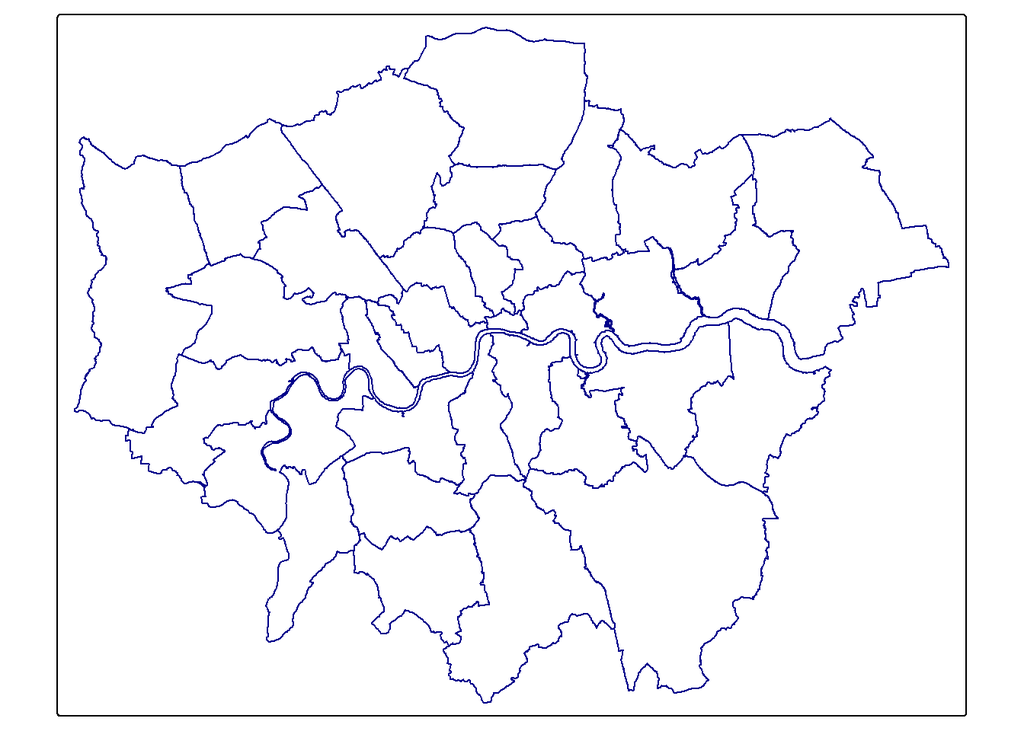

Add information to the map

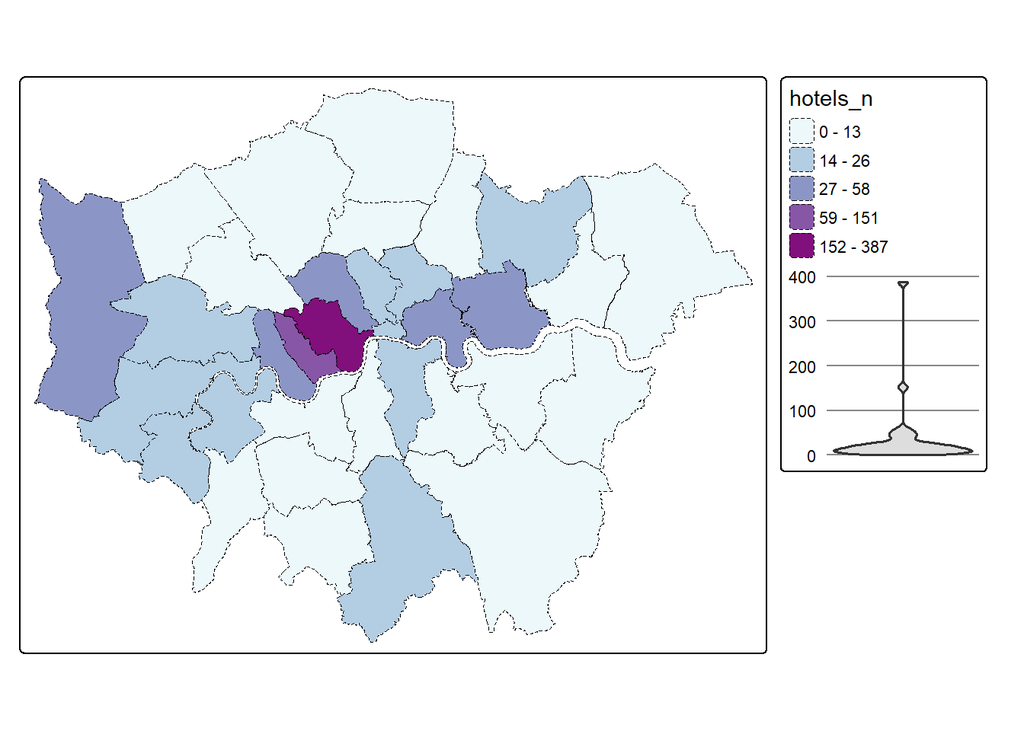

  options see the tmap chart vigette.

  More colors with brewer.bu_pu

setting up breaks across two data sets

using the airbnb as the greatest range and apply them to both data sets

Not let’s make the maps for Hotels and Airbnbs as per the original plan. Because we have our

data of interest in two separate we have a few options:

Make a tmap object for each dataset (i.e. the same as above but now for airbnb)